# Mindful Living Collective - Summary Snapshot

Published

August 31, 2026

⬇ Download PDF

[figure not shown]

*Soldotna, Alaska | Data through December 2025*

Mindful Living Collective (MLC) operates *The Goods* (retail), *Where It’s At!* (restaurant and catering), and serves as community home for the Kenai Local Food Connection in Soldotna, Alaska. Established in December 2021 with a mission of empowering local farmers, food manufacturers, artists, and entrepreneurs, MLC is one of the central Kenai Peninsula’s primary hubs for locally grown and locally made food goods.

## Community Impact

Alaska imports the vast majority of its food. Since opening, MLC has worked to change that locally:

- $1,855,807 in total retail sales through December 2025
- $204,026 in direct local food purchases from 185 local farmers and food manufacturers
- Goods sold or consigned from more than 60 local artists, makers, and entrepreneurs
- Hundreds of free meals provided through the Everybody Eats program
- [Stay Healthy Food Boxes](https://www.thegoodsalaska.com/product/stay-healthy-food-box-subscription/2752) delivered to low-income tribal elders in partnership with the [Kenai Local Food Connection](https://www.kenailocalfood.org/stay-healthy) and the [Salamatof Tribe](https://salamatoftribe.com/)
- Community home for the Kenai Local Food Connection and anchor for dozens of local food, music, and arts events

## The Value of Sustaining MLC

Multiple studies by [Civic Economics](https://amiba.net/local-multiplier/) and the [Institute for Local Self-Reliance](https://ilsr.org/) find that purchases at local independent businesses recirculate roughly three to four times more money in the local economy than equivalent spending at national chains - on average, about 53 cents of every dollar at a local independent recirculates locally, compared to roughly 14 cents at a chain store. Every purchase at MLC circulates through local wages, local farms, and local families rather than leaving the peninsula.

The programs listed above exist because the business exists. If MLC closes, they close with it - there is no obvious local replacement for the food access, elder nutrition support, and community programming MLC provides.

MLC is also the operating home of the Kenai Local Food Connection and a year-round market anchor for local producers. Rebuilding this infrastructure from scratch would take years and significant investment. Sustaining it requires far less.

## Financial Snapshot

| Profit & Loss history | November 2021 — December 2025 (50 months, cash basis) |
| --- | --- |
| Lifetime retail sales | $1,855,807 |
| Cumulative net income (all time) | -$173,582 |

The business moved toward breakeven through 2023-2024, with mid-2025 being the most stable period. Revenue has declined in early 2026; the full report provides a detailed month-by-month breakdown and viability analysis.

## Business Expenses by Category

Payroll is by far the largest operating expense. Rent and utilities reflect the cost of maintaining a physical community space.

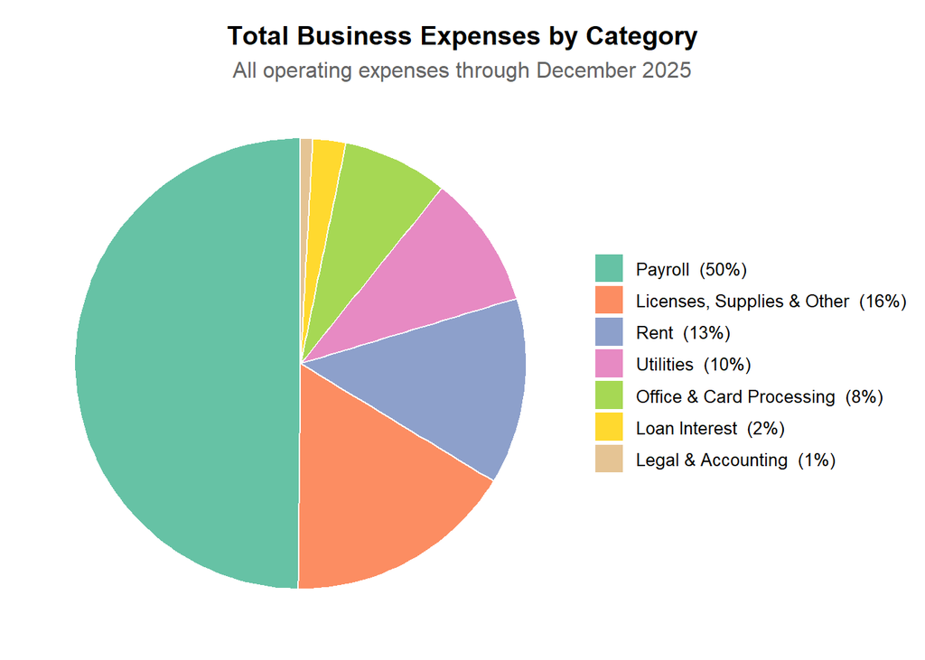

## Cost of Goods by Category

Local produce, eggs, meat, and other locally grown products represent the single largest category of MLC’s purchasing - a direct reflection of the business’s commitment to supporting local producers.

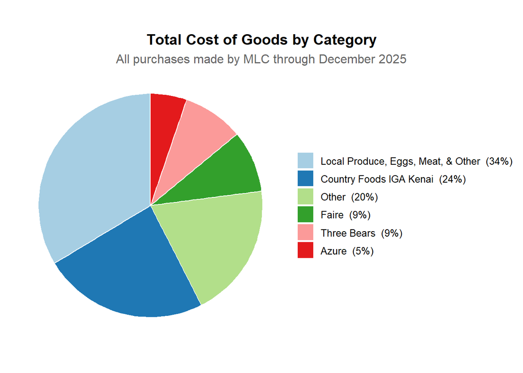

## Local Food Purchases

MLC purchases local produce, eggs, meat, and other locally grown and manufactured food products directly from Alaskan farmers and producers - a total of $204,026 since opening. The chart below shows annual growth in local foods spending by year.

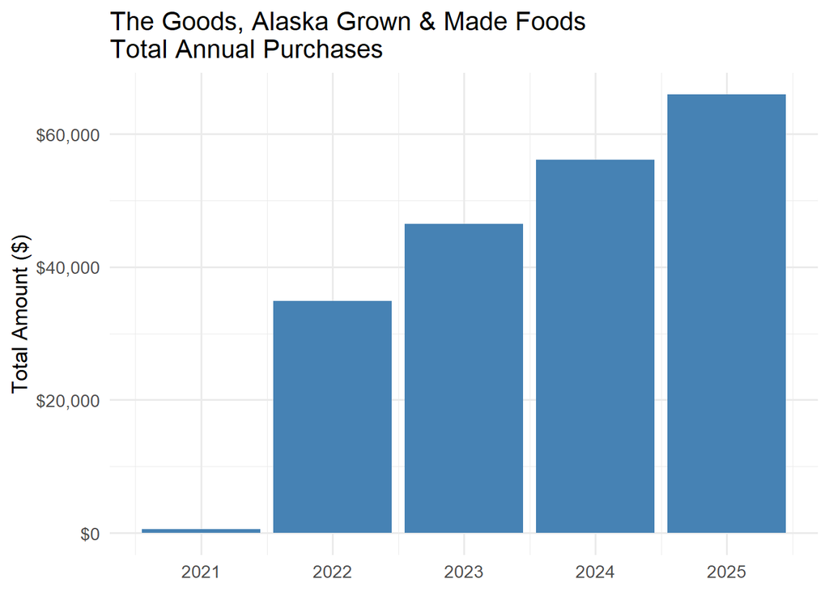

## Closing the Gap

MLC needs roughly $31,242.65 per month to cover fixed costs. For some months in 2025 the business exceeded this. However, seasonal slow months can dip below it: November 2025 is a recent example, with a gap of roughly $7,078.52. Early 2026 has been anomalously low and well below what is needed to cover fixed expenses. The short-term goal is to get back above the floor and stay there.

Reaching the floor consistently could happen several ways:

- **More retail visits:** at the 2025 average transaction of $34.30, closing a $7,078.52/month gap requires roughly 206 additional transactions per month — about 6.9 more per day.
- **Produce subscriptions:** at the minimum rate of $55/week, each weekly subscriber contributes $238.33/month. Roughly 30 subscribers would close a gap of this size entirely on their own.
- **Catering and events:** additional bookings contribute at a higher margin and are among the fastest ways to move the revenue needle.
- **Direct financial support:** owner-investment and community investment opportunities are available for those who want to play a larger role.

Every customer who shows up, every booking made, and every subscription renewed directly moves the needle. To learn more about investment opportunities or to get involved, contact Willow King at thegoodsalaska@gmail.com.

*For the full report, visit https://bit.ly/thegoodsalaska. Contact: Willow King (thegoodsalaska(at)gmail.com) or Benjamin Meyer (rivuletresearch(at)gmail.com).*

To access https://bit.ly/thegoodsalaska scan the QR code below with your smart phone.

[figure not shown]